# Practicum1_SUN

Mengyue Sun

10/7/2018

# Problem 1

1. Download the data set Glass Identification Database along with its explanation.

```r
glass <- read.csv("/Users/sunmengyue/Dropbox/2. Northeastern Unviersity/Fall2018/DA 5030 DataMining and Machine Learning/week4/practicum/glass.data.csv", header = FALSE, sep = ",")
names(glass) <- c("Id", "RI", "Na", "Mg", "Al", "Si", "K", "Ca", "Ba", "Fe", "glassType")
# Add column names to the dataset
```

2.Explore the data set as you see fit and that allows you to get a sense of the data and get comfortable with it.

```r
str(glass)
```

```
## 'data.frame':    214 obs. of  11 variables:
##  $ Id       : int  1 2 3 4 5 6 7 8 9 10 ...
##  $ RI       : num  1.52 1.52 1.52 1.52 1.52 ...
##  $ Na       : num  13.6 13.9 13.5 13.2 13.3 ...
##  $ Mg       : num  4.49 3.6 3.55 3.69 3.62 3.61 3.6 3.61 3.58 3.6 ...
##  $ Al       : num  1.1 1.36 1.54 1.29 1.24 1.62 1.14 1.05 1.37 1.36 ...
##  $ Si       : num  71.8 72.7 73 72.6 73.1 ...
##  $ K        : num  0.06 0.48 0.39 0.57 0.55 0.64 0.58 0.57 0.56 0.57 ...
##  $ Ca       : num  8.75 7.83 7.78 8.22 8.07 8.07 8.17 8.24 8.3 8.4 ...
##  $ Ba       : num  0 0 0 0 0 0 0 0 0 0 ...
##  $ Fe       : num  0 0 0 0 0 0.26 0 0 0 0.11 ...
##  $ glassType: int  1 1 1 1 1 1 1 1 1 1 ...
```

```r
# transform the glassType into factor.First we take a look at what types are there
unique(glass$glassType)
```

```
## [1] 1 2 3 5 6 7
```

```r
glass$glassType <- factor(glass$glassType,
                     labels = c("buildingFloat", "buildingNonFloat",
                                "vehicleFloat", "containers", "tableware", "headlamps"))
class(glass$glassType)
```

```
## [1] "factor"
```

```r
summary(glass[, 3:10])
```

```
##        Na              Mg              Al              Si
##  Min.   :10.73   Min.   :0.000   Min.   :0.290   Min.   :69.81
##  1st Qu.:12.91   1st Qu.:2.115   1st Qu.:1.190   1st Qu.:72.28
##  Median :13.30   Median :3.480   Median :1.360   Median :72.79
##  Mean   :13.41   Mean   :2.685   Mean   :1.445   Mean   :72.65
##  3rd Qu.:13.82   3rd Qu.:3.600   3rd Qu.:1.630   3rd Qu.:73.09
##  Max.   :17.38   Max.   :4.490   Max.   :3.500   Max.   :75.41
##        K                Ca               Ba              Fe
##  Min.   :0.0000   Min.   : 5.430   Min.   :0.000   Min.   :0.00000
##  1st Qu.:0.1225   1st Qu.: 8.240   1st Qu.:0.000   1st Qu.:0.00000
##  Median :0.5550   Median : 8.600   Median :0.000   Median :0.00000
##  Mean   :0.4971   Mean   : 8.957   Mean   :0.175   Mean   :0.05701
##  3rd Qu.:0.6100   3rd Qu.: 9.172   3rd Qu.:0.000   3rd Qu.:0.10000
##  Max.   :6.2100   Max.   :16.190   Max.   :3.150   Max.   :0.51000
```

3.Create a histogram of the Na column and overlay a normal curve; visually determine whether the data is normally distributed. Does the k-NN algorithm require normally distributed data or is it a non-parametric method?

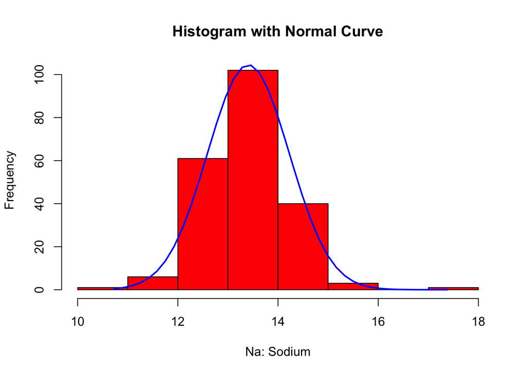

```r
NaData <- glass$Na
h <- hist(NaData, col = "red", xlab = "Na: Sodium", main="Histogram with Normal Curve")
xfit<-seq(min(NaData),max(NaData),length=40)
yfit<-dnorm(xfit,mean=mean(NaData),sd=sd(NaData))
yfit <- yfit*diff(h$mids[1:2])*length(NaData)
lines(xfit, yfit, col="blue", lwd=2)
```

The histogram presents to be normally distributed.It shows that the mean, median, and mode are around 13.5. The k-NN algorithm does not require normally distributed data and it is a non-parametric method.

4.After removing the ID column (column 1), normalize the first two columns in the data set using min-max normalization.

```r
#remove the first column and assign the data to glass2
glass2 <- glass[, -1]

#create a function called normalize
normalize <- function(x) {
   return( (x - min(x)) / ( max(x) - min(x) ) )
}

#normalize the first 2 columns and save them to glass2
glassSub <- as.data.frame(lapply(glass2[, c(1:2)], normalize))
head(glassSub)
```

```
##          RI        Na
## 1 0.4328358 0.4375940
## 2 0.2835821 0.4751880
## 3 0.2208077 0.4210526
## 4 0.2857770 0.3729323
## 5 0.2752414 0.3819549
## 6 0.2111501 0.3097744
```

```r
summary(glassSub)
```

```
##        RI               Na
##  Min.   :0.0000   Min.   :0.0000
##  1st Qu.:0.2358   1st Qu.:0.3274
##  Median :0.2867   Median :0.3865
##  Mean   :0.3167   Mean   :0.4027
##  3rd Qu.:0.3515   3rd Qu.:0.4654
##  Max.   :1.0000   Max.   :1.0000
```

```r
glass2[, 1:2] <- glassSub
```

5.Normalize the remaining columns, except the last one, using z-score standardization

```r
#create a function named normalizeZ
normalizeZ <- function(x){
  return( (x - mean(x)) / sd(x) )
}

#normalize the remaining columns and save them to glass2
glassSub2 <- as.data.frame(lapply(glass2[, c(3:9)], normalizeZ))
head(glassSub2)
```

```
##          Mg         Al          Si           K         Ca         Ba
## 1 1.2517037 -0.6908222 -1.12444556 -0.67013422 -0.1454254 -0.3520514
## 2 0.6346799 -0.1700615  0.10207972 -0.02615193 -0.7918771 -0.3520514
## 3 0.6000157  0.1904651  0.43776033 -0.16414813 -0.8270103 -0.3520514
## 4 0.6970756 -0.3102663 -0.05284979  0.11184428 -0.5178378 -0.3520514
## 5 0.6485456 -0.4104126  0.55395746  0.08117845 -0.6232375 -0.3520514
## 6 0.6416128  0.3506992  0.41193874  0.21917466 -0.6232375 -0.3520514
##           Fe
## 1 -0.5850791
## 2 -0.5850791
## 3 -0.5850791
## 4 -0.5850791
## 5 -0.5850791
## 6  2.0832652
```

```r
summary(glassSub2)
```

```
##        Mg                Al                Si                K
##  Min.   :-1.8611   Min.   :-2.3132   Min.   :-3.6679   Min.   :-0.76213
##  1st Qu.:-0.3948   1st Qu.:-0.5106   1st Qu.:-0.4789   1st Qu.:-0.57430
##  Median : 0.5515   Median :-0.1701   Median : 0.1795   Median : 0.08884
##  Mean   : 0.0000   Mean   : 0.0000   Mean   : 0.0000   Mean   : 0.00000
##  3rd Qu.: 0.6347   3rd Qu.: 0.3707   3rd Qu.: 0.5636   3rd Qu.: 0.17318
##  Max.   : 1.2517   Max.   : 4.1162   Max.   : 3.5622   Max.   : 8.75961
##        Ca                Ba                Fe
##  Min.   :-2.4783   Min.   :-0.3521   Min.   :-0.5851
##  1st Qu.:-0.5038   1st Qu.:-0.3521   1st Qu.:-0.5851
##  Median :-0.2508   Median :-0.3521   Median :-0.5851
##  Mean   : 0.0000   Mean   : 0.0000   Mean   : 0.0000
##  3rd Qu.: 0.1515   3rd Qu.:-0.3521   3rd Qu.: 0.4412
##  Max.   : 5.0824   Max.   : 5.9832   Max.   : 4.6490
```

```r
glass2[, 3:9] <- glassSub2
summary(glass2)
```

```
##        RI               Na               Mg                Al
##  Min.   :0.0000   Min.   :0.0000   Min.   :-1.8611   Min.   :-2.3132
##  1st Qu.:0.2358   1st Qu.:0.3274   1st Qu.:-0.3948   1st Qu.:-0.5106
##  Median :0.2867   Median :0.3865   Median : 0.5515   Median :-0.1701
##  Mean   :0.3167   Mean   :0.4027   Mean   : 0.0000   Mean   : 0.0000
##  3rd Qu.:0.3515   3rd Qu.:0.4654   3rd Qu.: 0.6347   3rd Qu.: 0.3707
##  Max.   :1.0000   Max.   :1.0000   Max.   : 1.2517   Max.   : 4.1162
##        Si                K                  Ca                Ba
##  Min.   :-3.6679   Min.   :-0.76213   Min.   :-2.4783   Min.   :-0.3521
##  1st Qu.:-0.4789   1st Qu.:-0.57430   1st Qu.:-0.5038   1st Qu.:-0.3521
##  Median : 0.1795   Median : 0.08884   Median :-0.2508   Median :-0.3521
##  Mean   : 0.0000   Mean   : 0.00000   Mean   : 0.0000   Mean   : 0.0000
##  3rd Qu.: 0.5636   3rd Qu.: 0.17318   3rd Qu.: 0.1515   3rd Qu.:-0.3521
##  Max.   : 3.5622   Max.   : 8.75961   Max.   : 5.0824   Max.   : 5.9832
##        Fe                     glassType
##  Min.   :-0.5851   buildingFloat   :70
##  1st Qu.:-0.5851   buildingNonFloat:76
##  Median :-0.5851   vehicleFloat    :17
##  Mean   : 0.0000   containers      :13
##  3rd Qu.: 0.4412   tableware       : 9
##  Max.   : 4.6490   headlamps       :29
```

6. The data set is sorted, so creating a validation data set requires random selection of elements. Create a stratified sample where you randomly select 50% of each of the cases for each glass type to be part of the validation data set. The remaining cases will form the training data set

```r
#Create a dataset in random selection order
set.seed(123)
gp <- runif(nrow(glass2))
glass2 <- glass2[order(gp), ]
head(glass2, 15)
```

```
##            RI        Na         Mg           Al          Si           K
## 74  0.2265145 0.3924812  0.6138814  0.250552901  0.28283082  0.17317592
## 143 0.2401229 0.3187970  0.5722842 -0.009827439  0.46358191  0.28050631
## 35  0.2932397 0.2947368  0.5930828 -0.210120008  0.38611716  0.11184428
## 18  0.4745391 0.5458647  0.8080012 -1.111436569 -1.66669884 -0.53213802
## 6   0.2111501 0.3097744  0.6416128  0.350699185  0.41193874  0.21917466
## 51  0.5289728 0.4496241  0.7178741 -1.872548332 -1.16317794 -0.62413549
## 113 0.7295874 0.2872180 -1.8611468 -1.552080221 -0.81458654 -0.67013422
## 148 0.2172959 0.3909774  0.5861500 -0.210120008  0.02461497  0.09651136
## 128 0.4240562 0.4586466 -0.2804565 -0.029856696 -0.85331892 -0.01081902
## 98  0.2756804 0.2210526  0.3920301 -0.570646633  1.16076470  0.18850884
## 62  0.3784021 0.4631579  0.6208142 -0.250178522 -1.20191031 -0.57813675
## 85  0.1290606 0.5293233  0.2811045  1.272045003 -0.47890594  0.92448860
## 15  0.2844601 0.2827068  0.6277471 -0.270207779  0.82508410  0.12717719
## 155 0.2541703 0.3203008  0.6208142 -0.270207779 -0.05284979  0.17317592
```

[output cut: 17 more lines]